# Homework 4: ACS Income Prediction

This homework assignment guides you through building and evaluating machine learning models to predict individual income using the American Community Survey (ACS) microdata. You will implement both an XGBoost model and a fully connected neural network using Keras, following the workflows demonstrated in the provided tutorials. The focus will be on log-transforming the income target, feature engineering, model training, and evaluation.

## Setup

```r
rm(list=ls())
```

The below section was generated by the GitHub chat agent after several hours of trying to get Tensorflow working on my RAND laptop.

```r
Sys.setenv(RETICULATE_PYTHON = "C:/r-tf/Scripts/python.exe")
#logfile <- "submit.log"
#sink(logfile, append = FALSE, split = TRUE)
rm(list=ls())

if(Sys.getenv("RETICULATE_PYTHON") == "") {
  Sys.setenv(RETICULATE_PYTHON = "C:/Users/jgluckman/AppData/Local/r-reticulate/r-reticulate/pyenv/pyenv-win/versions/3.11.9/python.exe")
} else {
   #cat("Using RETICULATE_PYTHON=", Sys.getenv("RETICULATE_PYTHON"), "\n")
  }
```

```r
pacman::p_load(xgboost, neuralnet, keras3, reticulate, tensorflow, tidyverse, rio)
```

More Chat input

```r
py_path <- Sys.getenv("RETICULATE_PYTHON")
if(py_path != "") {
  use_python(py_path, required = TRUE)
 } else {
   use_python("C:\\Users\\jgluckman\\AppData\\Local\\r-reticulate\\r-reticulate\\pyenv\\pyenv-win\\versions\\3.11.9\\python.exe", required=TRUE)
}
```

```r
setwd("C:\\Users\\jgluckman\\OneDrive - RAND Corporation\\Desktop\\Machine Learning\\PRGS-Intro-to-ML-2025\\")
data <- import("data\\raw\\usa_00005.dta")
data.back <- data
```

Additional Chat fix for Python package errors

```r
if(!"keras" %in% loadedNamespaces()) {
   tryCatch(library(keras), error = function(e) print(paste("Warning: could not load keras: ", conditionMessage(e), "\n")))
 }
```

```
[1] "Warning: could not load keras:  there is no package called 'keras' \n"
```

```r
if(!"tensorflow" %in% loadedNamespaces()) {
   tryCatch(library(tensorflow), error = function(e) print(paste("Warning: could not load tensorflow: ", conditionMessage(e), "\n")))
 }
 if(!exists("keras_model_sequential")) {
   if(exists("keras_model_sequential", where = asNamespace("keras"), inherits = FALSE)) {
     assign("keras_model_sequential", get("keras_model_sequential", envir = asNamespace("keras")), envir = .GlobalEnv)
   }
 }
```

### Data

Use the ACS microdata file `usa_00005.dta` that I shared on Populi. This dataset contains individual-level records with demographic and socioeconomic features, including total personal income (`inctot`).

## Task 1: Load and Log-transform ACS Data

Following the final attempt in the XGBoost tutorial, sample 10% of the microdata, drop any rows where `inctot == 9999999`.

```r
sel <- sample(1:10, nrow(data), replace = TRUE)
data <- data[sel == 1,]
data <- data[!(data$inctot == 9999999),]
```

**Quesion 1:** Why is it not necessary to impute or filter our missing values for other features?

Since `inctot` is our dependent variable, it is important to make sure that that column specifically is complete. However, the other variables are all independent inputs, and exist in enough quantity that some loss is negligible for purposes of this assignment.

### Task 1.1: Log-transform Income

Instead of predicting income directly, we will predict log-income. Create a new target column `log_inctot` by applying the natural log transformation to `inctot` after adding 1 (i.e., `np.log1p`). Filter out any rows where `inctot` is less than or equal to zero before applying the log transformation. Make a histogram of both the original income and log-income distributions to visualize the effect of the transformation.

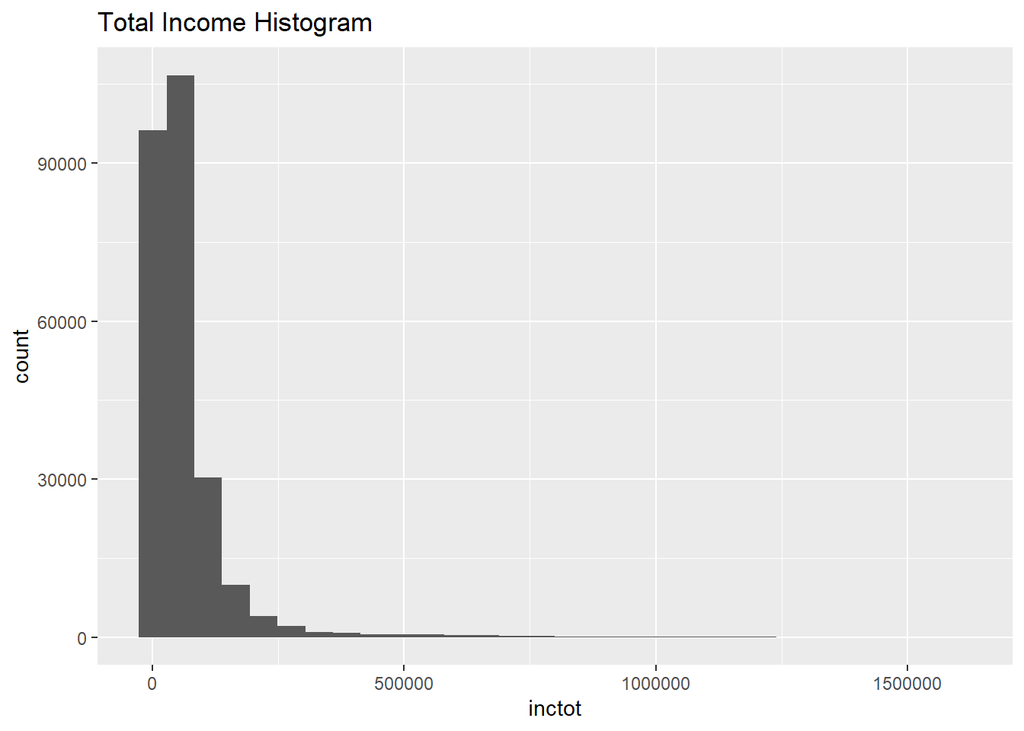

```r
data <- data[data$inctot > 0,]
data$log_inctot <- log1p(data$inctot + 1)
ggplot(data) +
  geom_histogram(aes(x = inctot)) +
  labs(title = "Total Income Histogram")
```

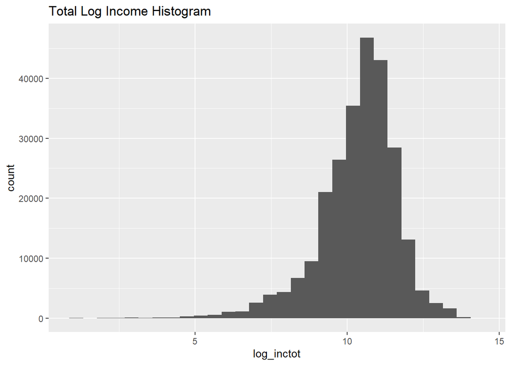

```r
ggplot(data) +
  geom_histogram(aes(x = log_inctot)) +
  labs(title = "Total Log Income Histogram")
```

```r
write.csv(data, "cleaned.csv")
```

**Question 2:** What are the advantages of predicting log-income rather than income directly? Log_income better centralizes results into a more even range, instead of containing a long tail for the extreme end of the data.

## Task 2: Feature Engineering and Encoding

Split the data into a feature matrix `X` and target vector `y` (the log-income column created above). Perform one-hot encoding on all categorical features, dropping sparse columns whose proportion of non-zero entries falls below 1%. The feature matrix `X` should include all columns except `inctot` and `log_inctot`. The target vector `y` should be the `log_inctot` column. Mimic the one-hot encoding workflow from the tutorial: build dummies for every categorical column in `X`, then drop sparse columns whose proportion of non-zero entries falls below 1%.

NOTE: CAN I DO THIS IN R?

```r
data <- read.csv("cleaned.csv")
X <- data
X$inctot <- NULL
X$log_inctot <- NULL
for(i in 1:ncol(X)){
  chk <- length(X[i][X[i] == 0,]) / nrow(X)
  if(chk > 0.99){
    X[1, i] <- 999999
  }
}
X[,X[1,] == 999999] <- NULL
y <- data$log_inctot
```

### Task 2.1: Train/Test Split

Split the encoded data into training and testing sets (80/20).

```r
train.perc <- 0.8
train.size <- round(train.perc*nrow(data))
test.size <- nrow(data) - train.size
assigns <- sample(0:1, prob = c(train.perc, (1-train.perc)))
train.y <- y[assigns == 0]
test.y <- as.numeric(y[assigns == 1])
train.x <- as.matrix(X[assigns == 0,])
test.x <- as.matrix(X[assigns == 1,])
```

## Task 3: XGBoost Modeling (Log Target)

Reproduce the final modeling attempt from `examples/XGBoost.ipynb`, but treat the log-income target as the label. Work through the following subtasks and insert your own code in each block.

### Task 3.1: Build DMatrix Objects

Create `xgb.DMatrix` objects for both the training and test splits using the log-income labels.

```r
xgb.train <- xgb.DMatrix(data = train.x, label = train.y)
xgb.test <- xgb.DMatrix(data = test.x, label = test.y)
```

### Task 3.2: Hyperparameter Dictionary

Start from the tutorial’s baseline settings (e.g., `eta = 1`, `max_depth = 10`, `min_child_weight = 100`, RMSE metric, early stopping after 50 rounds) and justify any deviations you make. Use the `reg:squarederror` objective and `rmse` evaluation metric.

R runs the training first and then adds parameters

```r
xgb.train <- xgboost(xgb.train, params = list(eta = 1, max_depth = 10), nrounds = 10000, verbose = FALSE, metrics = "rmse", objective = "reg:squarederror")
```

```
[13:52:53] WARNING: src/learner.cc:767:
Parameters: { "metrics" } are not used.
```

### Task 3.3: Hyperparameter Tuning

Perform a grid search over the `eta = [1, 0.1, 0.01]` and `max_depth = [3, 6, 10]` parameters to identify the best combination based on validation RMSE (i.e., for each combination of `eta` and `max_depth`, train a model and record the validation RMSE). Use early stopping with a patience of 50 rounds and a maximum of 10,000 training rounds.

```r
etas <- c(1, 0.1, 0.1)
depths <- c(3, 6, 10)
finals <- cbind.data.frame(c(0, 0, 0), c(0, 0, 0), c(0, 0, 0))
names(finals) <- etas
rownames(finals) <- depths
for(i in 1:length(etas)){
  for(j in 1:length(depths)){
    xgb.tmp <- xgboost(train.x, label = train.y, params = list(eta = etas[i], max_depth = depths[j]), nrounds = 10000, verbose = FALSE, metrics = "rmse", objective = "reg:squarederror")
    finals[j, i] <- xgb.tmp$evaluation_log[nrow(xgb.tmp$evaluation_log)][[2]]
  }
}
```

[output not shown]

```r
print(finals)
```

```
              1         0.1         0.1
3  0.3129007668 0.632940537 0.632940537
6  0.0009989506 0.149715586 0.149715586
10 0.0007119195 0.003146049 0.003146049
```

**Question 3:** Which hyperparameter combination yielded the lowest validation RMSE, and what was that RMSE value? Based on the results, do you think you need to expand the grid search other values or parameters? (Note: You do not need to actually search for more parameters, just discuss.)

Higher eta and higher depth are the most hyperspecific outputs, which will overfit results but remove rmse

### Task 3.4: Final Model Training

Using the best hyperparameters from Task 3.3, train a final XGBoost model on the full dataset.

```r
datamatrix <- xgb.DMatrix(data = as.matrix(X), label = data$log_inctot)
xgb.fin <- xgboost(data = datamatrix, label = train.y, params = list(eta = 1, max_depth = 10), nrounds = 10000, verbose = FALSE, metrics = "rmse", objective = "reg:squarederror")
```

```
[17:08:36] WARNING: src/learner.cc:767:
Parameters: { "metrics" } are not used.
```

### Task 3.5: Evaluate Predictions

Plot predicted vs. actual log-income values on the test set using a scatter plot.

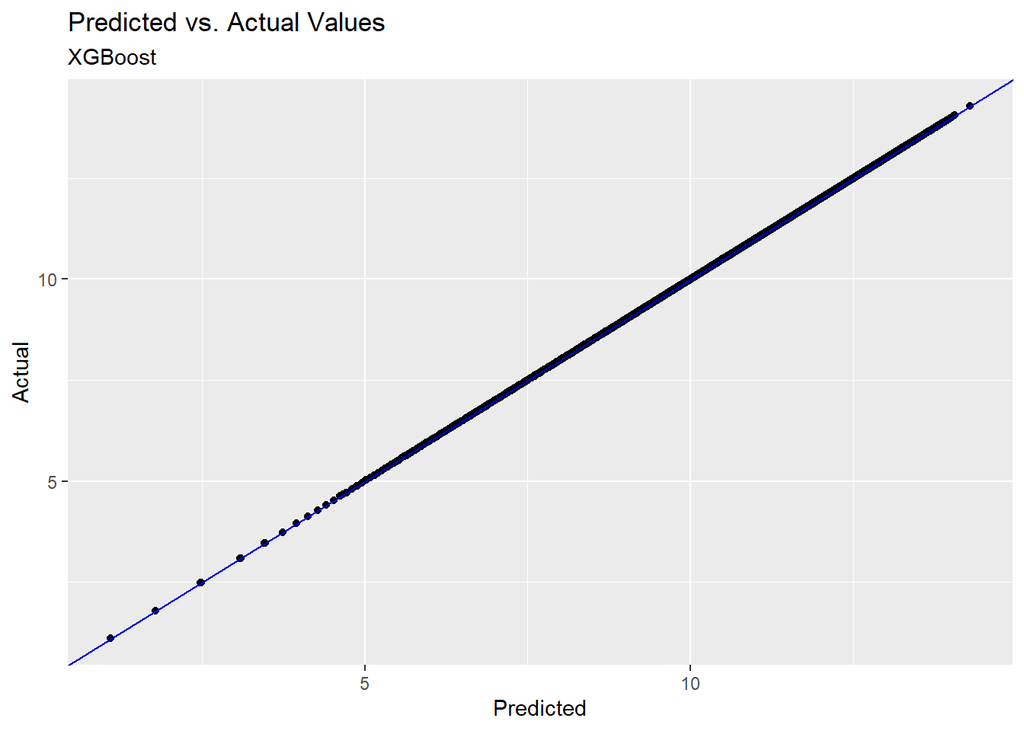

```r
preds.xgb <- predict(xgb.fin, newdata = test.x)
mse <- sum((preds.xgb-test.y)^2)/length(preds.xgb)
slope <- mean(test.y/preds.xgb)
ggplot() +
geom_point(aes(x = preds.xgb, y = test.y)) +
geom_abline(slope = slope, color = "blue3") +
labs(title = "Predicted vs. Actual Values", subtitle = "XGBoost", x = "Predicted", y = "Actual")
```

**Question 4:** Qualitatively, how well do the predictions align with the actual values? The predictions align strongly, and according to the math, perfectly.

## Task 4: Neural Network Modeling (Keras)

Use the structure from `examples/neural_nets_simple.ipynb` to fit a fully connected neural network on the same encoded features and log-income target. Use the same train/test split as in Task 2.1.

### Task 4.1: Prepare Data for Keras

If necessary, convert the training and test feature matrices and target vectors into NumPy arrays suitable for Keras. **Note:** You may have already done this in Task 2.1.

```r
head(train.x)
```

```
    X year sample serial    cbserial hhwt   cluster statefip countyfip puma
1   6 2023 202301      6 2.02301e+12   52 2.023e+12        1       125 1202
3  18 2023 202301     18 2.02301e+12   77 2.023e+12        1         0 1100
5  27 2023 202301     27 2.02301e+12   30 2.023e+12        1         0 1100
7  30 2023 202301     30 2.02301e+12   55 2.023e+12        1         0 2500
9  44 2023 202301     44 2.02301e+12   19 2.023e+12        1         0 1901
11 64 2023 202301     64 2.02301e+12   40 2.023e+12        1         0 1901
   density metro strata gq farm ownershp ownershpd mortgage mortgag2 acrehous
1   1981.8     4 120201  4    1        0         0        0        0        0
3     27.8     0 110001  3    1        0         0        0        0        0
5     27.8     0 110001  4    1        0         0        0        0        0
7     62.2     1 250001  4    1        0         0        0        0        0
9    174.8     4 190101  3    1        0         0        0        0        0
11   174.8     4 190101  3    1        0         0        0        0        0
   mortamt1 mortamt2 taxincl insincl propinsr proptx99 owncost rent rentgrs
```

[output cut: 97 more lines]

```r
head(test.x)
```

```
    X year sample serial    cbserial hhwt   cluster statefip countyfip puma
2  17 2023 202301     17 2.02301e+12   45 2.023e+12        1         0 1801
4  20 2023 202301     20 2.02301e+12   26 2.023e+12        1         0 1404
6  29 2023 202301     29 2.02301e+12   59 2.023e+12        1         0  900
8  32 2023 202301     32 2.02301e+12    9 2.023e+12        1         0 1502
10 46 2023 202301     46 2.02301e+12   20 2.023e+12        1         0 2000
12 65 2023 202301     65 2.02301e+12   50 2.023e+12        1         0 1403
   density metro strata gq farm ownershp ownershpd mortgage mortgag2 acrehous
2   1820.3     4 180101  4    1        0         0        0        0        0
4   1919.1     4 140401  4    1        0         0        0        0        0
6    157.9     3  90001  3    1        0         0        0        0        0
8    170.3     3 150201  4    1        0         0        0        0        0
10    78.1     0 200001  3    1        0         0        0        0        0
12  2384.8     4 140301  4    1        0         0        0        0        0
   mortamt1 mortamt2 taxincl insincl propinsr proptx99 owncost rent rentgrs
```

[output cut: 97 more lines]

```r
head(train.y)
```

```
[1]  6.218600 10.309019  7.697121  6.218600  6.804615  7.091742
```

```r
head(test.y)
```

```
[1]  9.024252  9.127176  8.882114  8.824972 10.309019  9.210540
```

### Task 4.2: Define the Architecture

Implement a dense network with several ReLU-activated hidden layers (e.g., 256-128-64) and compile it with the Adam optimizer and MSE loss.

**Question 5:** What should the input dimension be for the first layer of the network be?

```r
mean.list.train <- lapply(data.frame(train.x), mean)
mean.list.test <- lapply(data.frame(test.x), mean)
sds.train <- sapply(data.frame(train.x), sd)
sds.test <- sapply(data.frame(test.x), sd)
train.xs <- scale(train.x, center = mean.list.train, scale = sds.train)
test.xs <- scale(test.x, center = mean.list.test, scale = sds.test)
model.a <- keras_model_sequential()
model.a %>%
layer_dense(units = 256, activation = "relu") %>%
layer_dense(units = 128, activation = "relu") %>%
layer_dense(units = 64, activation = "relu") %>%
layer_dense(units = 1)
model.a %>% compile(optimizer = "adam", loss = "mse")
```

### Task 4.3: Initial Training

Fit the model on the training data while validating on the test set. Run the training for a maximum of 1,000 epochs.

```r
model.a %>% fit(x = train.xs, y = train.y, epochs = 1000, batch_size = 1024, validation_split = 0.2, verbose = 0)
```

#### Task 4.3a

```r
preds.nn <- model.a$predict(test.xs)
```

[output not shown]

[output cut: 12 more lines]

[output not shown]

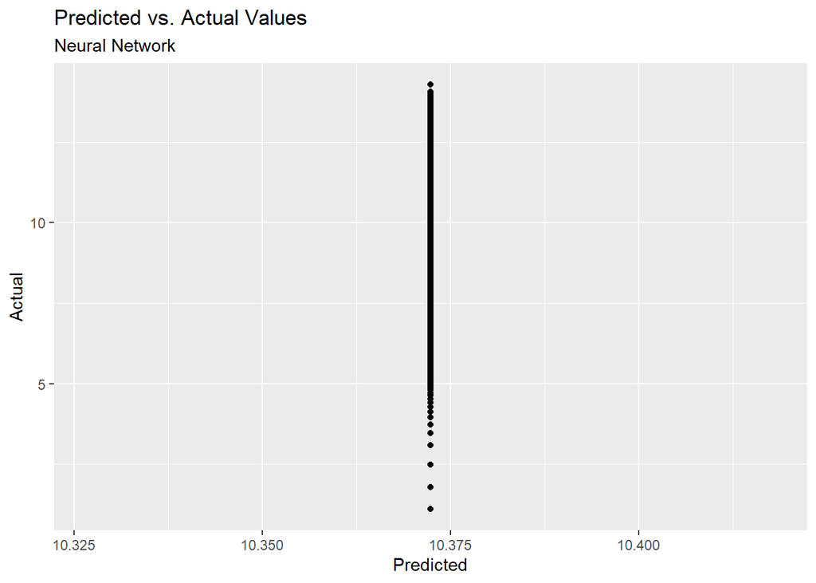

```r
mse <- as.numeric(mean(loss_mean_squared_error(preds.nn, test.y)))
slope <- mean(test.y/preds.nn)
ggplot() +
geom_point(aes(x = preds.nn, y = test.y)) +
geom_smooth(aes(x = preds.nn, y = test.y)) +
labs(title = "Predicted vs. Actual Values", subtitle = "Neural Network", x = "Predicted", y = "Actual")
```

### Task 4.4: Model Tuning

The neural network architecture and training parameters can significantly impact performance. The architecture consists of the number of layers, layer dimensions, and activation functions. Create three different architectures: the one from Task 4.2, a deeper/wider one, and a shallower/narrower one. Additionally, consider three different learning rates: `1e-3`, `1e-4`, and `1e-5`. Perform a grid search over these architectures and learning rates to identify the best combination based on validation loss. **Hint:** Save the models and their histories in a dictionary for easy comparison later.

```r
architectures <- c("classic", "deep", "shallow")
rates <- c(.001, .0001, .00001)
table <- cbind.data.frame(c(0, 0, 0), c(0, 0, 0), c(0, 0, 0))
names(table) <- architectures
rownames(table) <- rates
models <- list()
for(i in 1:nrow(table)){
  model.loc <- keras_model_sequential()
  model.loc %>%
    layer_dense(units = 256, activation = "relu") %>%
    layer_dense(units = 128, activation = "relu") %>%
    layer_dense(units = 64, activation = "relu") %>%
    layer_dense(units = 1)
  model.loc %>% compile(optimizer = optimizer_adam(learning_rate = rates[i]), loss = "mse")
  preds.tmp <- model.loc$predict(test.xs)
  mse.tmp <- as.numeric(mean(loss_mean_squared_error(preds.tmp, test.y)))
  models[[i]] <- model.loc
  table[i, 1] <- mse.tmp
}
```

[output not shown]

[output cut: 175 more lines]

[output not shown]

```r
for(i in 1:nrow(table)){
  model.loc <- keras_model_sequential()
  model.loc %>%
    layer_dense(units = 256, activation = "relu") %>%
    layer_dense(units = 128, activation = "relu") %>%
    layer_dense(units = 64, activation = "relu") %>%
    layer_dense(units = 32, activation = "relu") %>%
    layer_dense(units = 16, activation = "relu") %>%
    layer_dense(units = 1)
  model.a %>% compile(optimizer = optimizer_adam(learning_rate = rates[i]), loss = "mse")
  preds.tmp <- model.loc$predict(test.xs)
  mse.tmp <- as.numeric(mean(loss_mean_squared_error(preds.tmp, test.y)))
  models[[i + 3]] <- model.loc
  table[i, 2] <- mse.tmp
}
```

[output not shown]

[output cut: 173 more lines]

[output not shown]

```r
for(i in 1:nrow(table)){
  model.loc <- keras_model_sequential()
  model.loc %>%
    layer_dense(units = 64, activation = "relu") %>%
    layer_dense(units = 32, activation = "relu") %>%
    layer_dense(units = 1)
  model.a %>% compile(optimizer = optimizer_adam(learning_rate = rates[i]), loss = "mse")
  preds.tmp <- model.loc$predict(test.xs)
  mse.tmp <- as.numeric(mean(loss_mean_squared_error(preds.tmp, test.y)))
  models[[i + 6]] <- model.loc
  table[i, 3] <- mse.tmp
}
```

[output not shown]

[output cut: 121 more lines]

[output not shown]

```r
print(table)
```

```
       classic     deep  shallow
0.001 109.2566 109.2566 109.2566
1e-04 109.2566 109.2566 109.2566
1e-05 109.2566 109.2566 109.2566
```

### Task 4.5: Evaluate Predictions

Generate predictions on the test set using the best model from Task 4. Create a scatter plot of predicted vs. actual log-income values.

```r
model.b <- models[[1]]
preds.b <- model.b$predict(test.xs)
```

[output not shown]

[output cut: 19 more lines]

[output not shown]

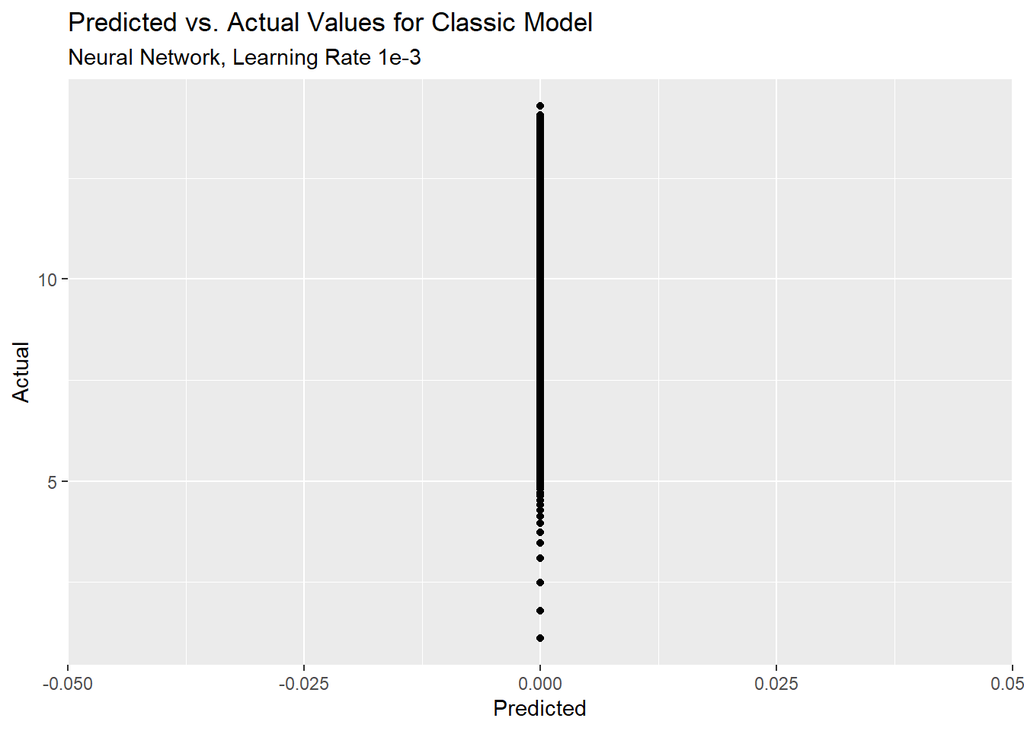

```r
mse.b <- table[1, 1]
slope <- mean(test.y/preds.b)
ggplot() +
geom_point(aes(x = preds.b, y = test.y)) +
geom_abline(slope = slope, color = "blue3") +
labs(title = "Predicted vs. Actual Values for Classic Model", subtitle = "Neural Network, Learning Rate 1e-3", x = "Predicted", y = "Actual")
```

## Task 5: Model Comparison and Reflection

Which model would you choose for predicting log-income on new ACS data: the XGBoost model from Task 3 or the neural network from Task 4? Why?